# Visualize Simon's Two-Stage Phase II Design

Tingting Zhan

# Introduction

This vignette of package **`VisualizeSimon2Stage`** ([CRAN](https://cran.r-project.org/package=VisualizeSimon2Stage), [Github](https://github.com/tingtingzhan/VisualizeSimon2Stage)) documents the visualization of probabilities and operating characteristics of Simon’s two-stage Phase II design.

## Getting Started

Examples in this vignette require that the `search` path has

```r
library(VisualizeSimon2Stage)
library(clinfun)
library(flextable)
library(ggplot2)
```

# Simon’s Two-Stage Phase II Design

## Notations

Simon’s two-stage design tests the one-sided hypothesis $H_0: p\leq p_u$ vs. $H_a: p>p_u$ for a binary response in the following steps.

1. Enroll $n_1$ subjects.
- **Early termination**, or **frail**, if $\leq r_1$ positive responses are observed.
- Move to next stage if $>r_1$ responses are observed.
2. Enroll an additional $(n-n_1)$ subjects.
- **Fail**, if $\leq r$ total responses are observed.
- **Success**, or $H_0$ rejected, if $>r$ total responses are observed.

In this vignette, $p_u$ denotes the unacceptable response rate, and $p_a$ denotes the acceptable response rate. The parameter nomenclature of $r_1$, $n_1$, $r$ and $n$ follows that of [`PASS`](https://www.ncss.com/software/pass/) and of the function [`clinfun::ph2simon()`](https://search.r-project.org/CRAN/refmans/clinfun/html/ph2simon.html).

Types of Simon’s two-stage design include

- `'minimax'` (default), minimum total sample size $n$
- `'optimal'`, minimum expected total sample size $\textrm{E}(n|p=p_u)$
- `'n1'`, minimum Stage-1 sample size $n_1$
- `'maximax'`, to use up the user-provided maximum total sample size, i.e., parameter `nmax` of function [`clinfun::ph2simon()`](https://search.r-project.org/CRAN/refmans/clinfun/html/ph2simon.html)
- `'all'`, all `type`s listed above

## `S3` class `'ph2simon'`

The function [`clinfun::ph2simon()`](https://search.r-project.org/CRAN/refmans/clinfun/html/ph2simon.html) returns an object of `S3` class `'ph2simon'`. The output is printed in the `R` console using `S3` method dispatch `clinfun:::print.ph2simon()`.

Example below provides the various Simon’s two-stage designs for hypotheses $p_u=.2$, $p_a=.4$, with Type-I error rate $\alpha=5\%$ and Type-II error rate $\beta=10\%$.

```r
(x = ph2simon(pu = .2, pa = .4, ep1 = .05, ep2 = .1))
```

```
 Simon 2-stage Phase II design

Unacceptable response rate:  0.2
Desirable response rate:  0.4
Error rates: alpha =  0.05 ; beta =  0.1

           r1 n1  r  n EN(p0) PET(p0)   qLo   qHi
Minimax     5 24 13 45  31.23  0.6559 0.108 1.000
Admissible  4 20 14 49  30.74  0.6296 0.058 0.108
Optimal     4 19 15 54  30.43  0.6733 0.000 0.058
```

## `S4` class `'ph2simon4'`

The function `ph2simon4()` converts an `S3` object `'ph2simon'` to an `S4` object `'ph2simon4'`. The output is printed in the `R` console using `S4` method dispatch `getMethod(f = 'show', signature = 'ph2simon4')`.

```r
x |>
  ph2simon4(type = 'all')
```

```
 Simon's 2-Stage Phase II Design

Unacceptable Response Rate: 20.0%
Desirable Response Rate: 40.0%
Controlled Error Rates: α ≤ 5%, β ≤ 10%
Maximum Sample Size Allowed: 100

        r1 n1  r   n EN(pu) EN(pa) PET(pu) PET(pa)    α     β
minimax  5 24 13  45   31.2   44.2   65.6%    4.0% 4.8% 10.0%
optimal  4 19 15  54   30.4   51.6   67.3%    7.0% 4.8%  9.6%
n1       3 15 19  71   34.7   65.9   64.8%    9.1% 4.5%  9.8%
maximax  7 27 28 100   38.4   93.0   84.4%    9.5% 1.2%  9.9%
```

# Probabilities

## Math

Given a Simon’s two-stage design $(r_1,n_1,r,n)$ and a true response rate $p$, we have

- the number of Stage-1 positive responses $X_1 \sim \textrm{binom}(n_1, p)$.
- the number of Stage-2 positive responses $X_2 \sim \textrm{binom}(n-n_1, p)$.
- $X_1$ and $X_2$ are independent.

The probability of early termination is

$$p_{\textrm{frail}} = \textrm{Pr}(X_1 \leq r_1)$$

The probability of failure to reject $H_0$ is

$$p_{\textrm{fail}} = \sum_{s_1 = r_1+1}^{n_1} \textrm{Pr}(X_1=s_1)\cdot\textrm{Pr}\left(X_2 \leq (r-s_1)\right)$$

The probability of successfully rejecting $H_0$ is

$$p_{\textrm{success}} = \sum_{s_1 = r_1+1}^{n_1} \textrm{Pr}(X_1=s_1)\cdot\textrm{Pr}(X_2 > (r-s_1))$$

The expected sample size is

$$\textrm{E}(n) = p_{\textrm{frail}} \cdot n_1 + (1 - p_{\textrm{frail}}) \cdot n$$

## Numbers

The S3 generic `simon_pr()` calculates the probabilities of early termination, fail and success at one-or-more response rates $p$, either from an `S3` object `'ph2simon'`,

```r
x |>
  simon_pr(prob = c(.2, .3, .4)) |>
  as_flextable()
```

| Response Rate | E(N) | Probabilities Early Termination | Probabilities Fail | Probabilities Success |
| --- | --- | --- | --- | --- |
| p = 20% | 31.2 | 65.6% | 29.6% | 4.8% |
| p = 30% | 40.2 | 22.9% | 30.3% | 46.8% |
| p = 40% | 44.2 | 4.0% | 6.0% | 90.0% |

or from an `S4` object `'ph2simon4'`,

```r
x |>
  ph2simon4() |>
  simon_pr(prob = c(.2, .3, .4)) |>
  as_flextable()
```

| Response Rate | E(N) | Probabilities Early Termination | Probabilities Fail | Probabilities Success |
| --- | --- | --- | --- | --- |
| p = 20% | 31.2 | 65.6% | 29.6% | 4.8% |
| p = 30% | 40.2 | 22.9% | 30.3% | 46.8% |
| p = 40% | 44.2 | 4.0% | 6.0% | 90.0% |

or from the design parameters $(r_1, n_1, r, n)$. In such case the user must call the `S3` method dispatch `simon_pr.ph2simon4()` explicitly.

```r
simon_pr.ph2simon4(prob = c(.2, .3, .4), r1 = 5L, n1 = 24L, r = 13L, n = 45L) |>
  as_flextable()
```

| Response Rate | E(N) | Probabilities Early Termination | Probabilities Fail | Probabilities Success |
| --- | --- | --- | --- | --- |
| p = 20% | 31.2 | 65.6% | 29.6% | 4.8% |
| p = 30% | 40.2 | 22.9% | 30.3% | 46.8% |
| p = 40% | 44.2 | 4.0% | 6.0% | 90.0% |

## Visualization

S3 methods dispatches for the generic `ggplot2::autoplot()` visualize the probabilities of early termination, fail and success at $p=p_u$ and $p=p_a$. The donut slices for success are colored with the highest opacity, indicating that they represent the Type-I error rate $\alpha$ if $p=p_u$, and the power $1-\beta$ if $p=p_a$. The probabilities are visualized either from an `S3` object `'ph2simon'`,

```r
x |>
  autoplot(type = 'optimal')
```

[output not shown]

or from an `S4` object `'ph2simon4'`.

```r
x |>
  ph2simon4(type = 'optimal') |>
  autoplot()
```

[output not shown]

or from the design parameters $(r_1, n_1, r, n)$ and `type`. In such case the user must call the `S3` method dispatch `autoplot.ph2simon4()` explicitly.

```r
autoplot.ph2simon4(pu = .2, pa = .4, r1 = 4L, n1 = 19L, r = 15L, n = 54L, type = 'optimal')
```

[output not shown]

## Simulation

The S3 generic `r_simon()` simulates the number of positive responses in Simon’s two-stage design. Following examples show simulations of `1e4L` trials at $p=.3$, either from an `S3` object `'ph2simon'`,

```r
set.seed(15); s = x |>
  r_simon(R = 1e4L, prob = .3, type = 'optimal')
```

or from an `S4` object `'ph2simon4'`,

```r
set.seed(15); s1 = x |>
  ph2simon4(type = 'optimal') |>
  r_simon(R = 1e4L, prob = .3)
stopifnot(identical(s, s1))
```

or from the design parameters $(r_1, n_1, r, n)$. In such case the user must call the `S3` method dispatch `r_simon.ph2simon4()` explicitly.

```r
set.seed(15); s2 = r_simon.ph2simon4(R = 1e4L, prob = .3, r1 = 4L, n1 = 19L, r = 15L, n = 54L)
stopifnot(identical(s, s2))
```

The Type-I error rate is controlled at $\alpha\leq 5\%$ when $p=p_u=.2$ at a sufficiently large simulated sample size. The Type-II error rate is controlled at $\beta\leq 10\%$, or power $(1-\beta)\geq 90\%$, when $p=p_a=.4$.

**R code: Type-I-error rate at $p_u$, `1e4L` simulated copies**

```r
set.seed(31); x |>
  r_simon(R = 1e4L, prob = .2) |>
  attr(which = 'dx', exact = TRUE) |>
  table(Decision = _) |>
  as_flextable() |>
  highlight(i = 3L, j = 3L) |>
  add_header_lines(values = 'pu = .2')
```

| pu = .2 Decision | pu = .2 Count | pu = .2 Percent |
| --- | --- | --- |
| [0,5]; Early Termination | 6,577 | 65.8% |
| (5,13]; Fail | 2,961 | 29.6% |
| (13,45]; Success | 462 | 4.6% |
| Total | 10,000 | 100.0% |

**R code: power at $p_a$, `1e4L` simulated copies**

```r
set.seed(24); x |>
  r_simon(R = 1e4L, prob = .4) |>
  attr(which = 'dx', exact = TRUE) |>
  table(Decision = _) |>
  as_flextable() |>
  highlight(i = 3L, j = 3L) |>
  add_header_lines(values = 'pa = .4')
```

| pa = .4 Decision | pa = .4 Count | pa = .4 Percent |
| --- | --- | --- |
| [0,5]; Early Termination | 379 | 3.8% |
| (5,13]; Fail | 583 | 5.8% |
| (13,45]; Success | 9,038 | 90.4% |
| Total | 10,000 | 100.0% |

# Power Curve

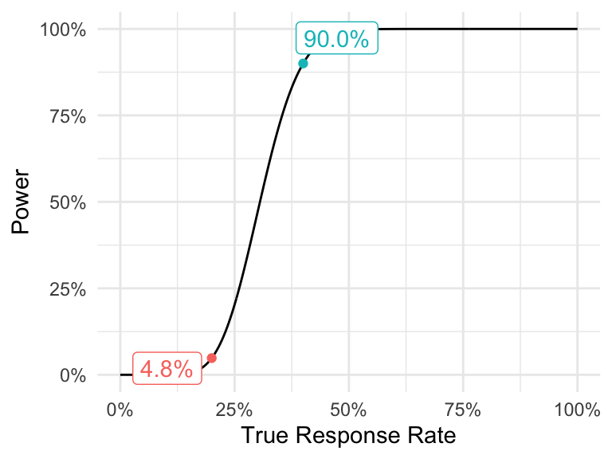

```r
x |>
  powerCurve.ph2simon()
```

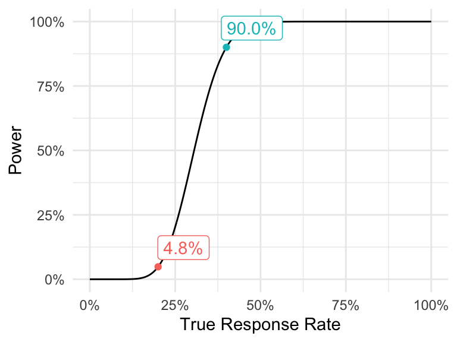

```r
x |>
  ph2simon4() |>
  powerCurve.ph2simon4()
```

# Operating Characteristics

Suppose we have three drugs $A$, $B$ and $C$, with true response rate $p^A=.3$, $p^B=.2$ and $p^C=.15$, respectively.

```r
p = c(A = .3, B = .2, C = .15)
```

We simulate `1e4L` Simon’s two-stage trials of each drug to obtain the operating characteristics, i.e., the percentage of trials in which each drug

- having the highest number of responses
- both having the highest number of responses *and* successfully rejecting the null hypothesis.

The operating characteristics are visualized either from an `S3` object `'ph2simon'`,

```r
set.seed(52); x |>
  simon_oc(prob = p, R = 1e4L, type = 'optimal')
```

[output not shown]

or from an `S4` object `'ph2simon4'`,

```r
set.seed(52); x |>
  ph2simon4(type = 'optimal') |>
  simon_oc(prob = p, R = 1e4L)
```

[output not shown]

or from the design parameters $(r_1, n_1, r, n)$. In such case the user must call the `S3` method dispatch `simon_oc.ph2simon4()` explicitly.

```r
set.seed(52); simon_oc.ph2simon4(prob = p, R = 1e4L, r1 = 4L, n1 = 19L, r = 15L, n = 54L)
```

[output not shown]